# Lab 11X

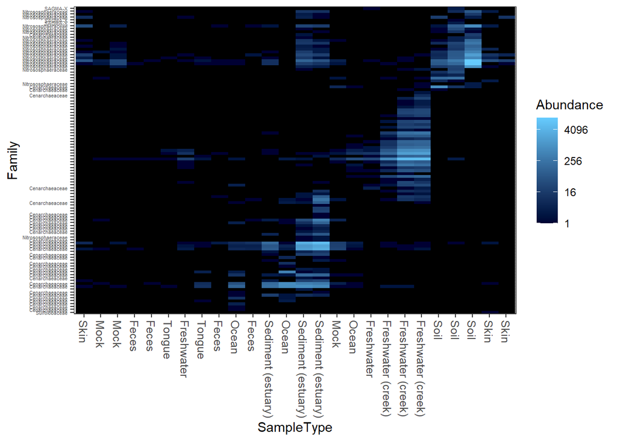

```r
plot_heatmap(gpac, "PCoA", "unifrac", "SampleType", "Family")
```

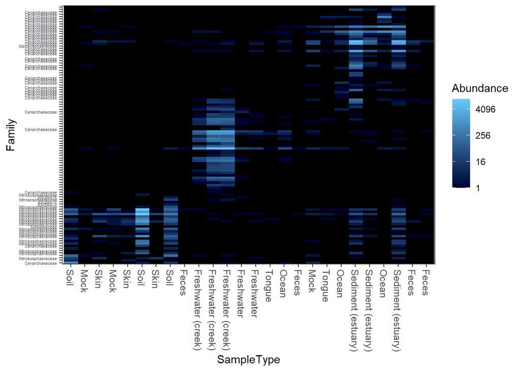

```r
plot_heatmap(gpac, "MDS", "unifrac", "SampleType", "Family", weighted=TRUE)
```

And here is somethign similar to what we have done previously with heirarchical clustering

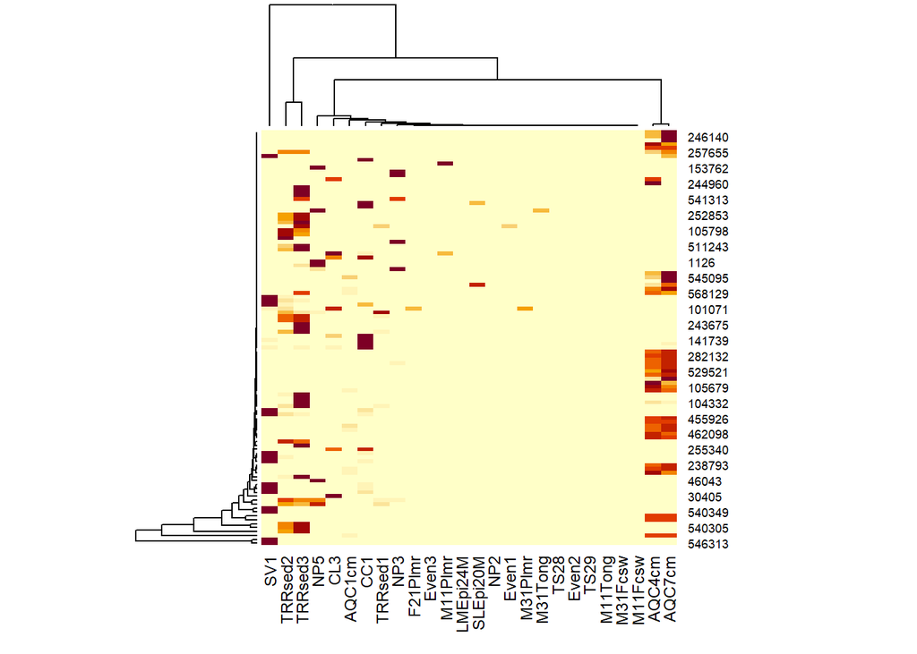

```r
heatmap(otu_table(gpac))
```

# Plot Microbiome Network

## Load Package and Example Data

```r
library(phyloseq); packageVersion("phyloseq")
```

```
## [1] '1.34.0'
```

```r
packageVersion("ggplot2")
```

```
## [1] '3.3.2'
```

```r
data(enterotype)
```

Set random seed for reproducibility

```r
set.seed(711L)
```

Remove NAs

```r
enterotype = subset_samples(enterotype, !is.na(Enterotype))
```

## The plot_net function

Try the defaults

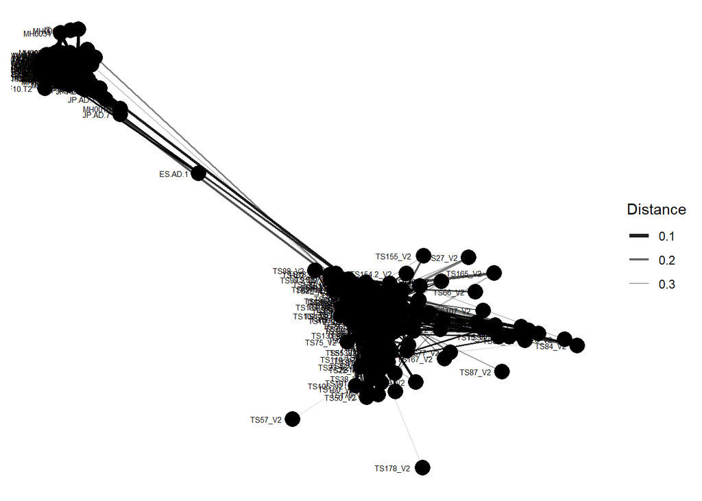

```r
plot_net(enterotype, maxdist = 0.4, point_label = "Sample_ID")
```

Let’s use some visual variabels to make sense of the patterns

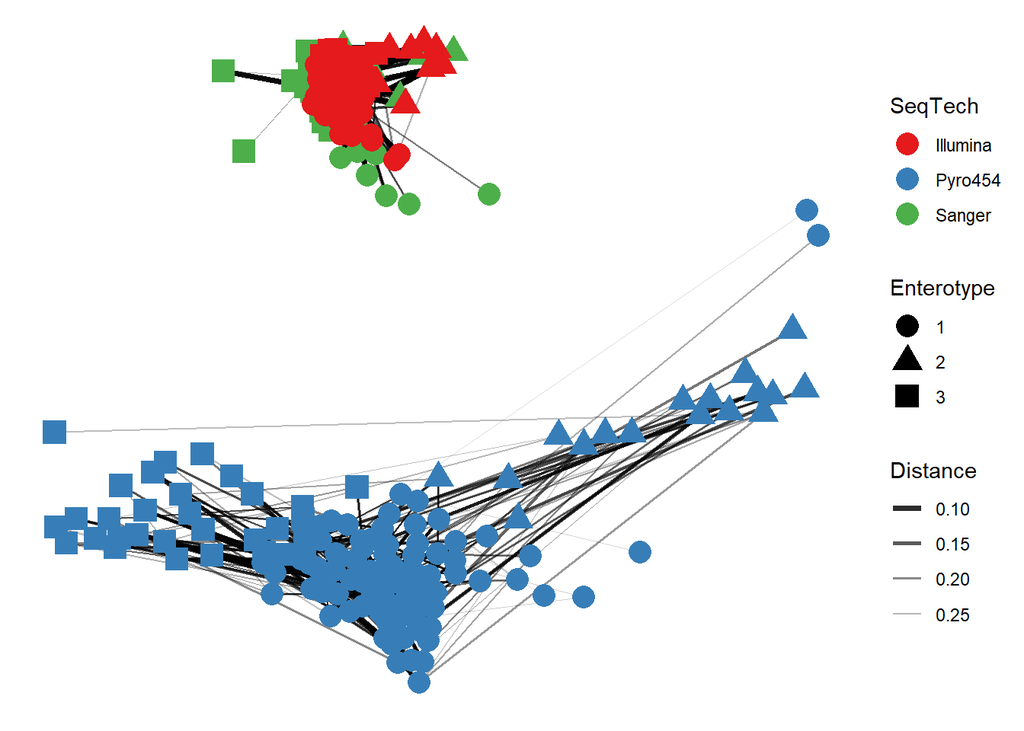

```r
plot_net(enterotype, maxdist = 0.3, color = "SeqTech", shape="Enterotype")
```

Trying at higher `maxdist`

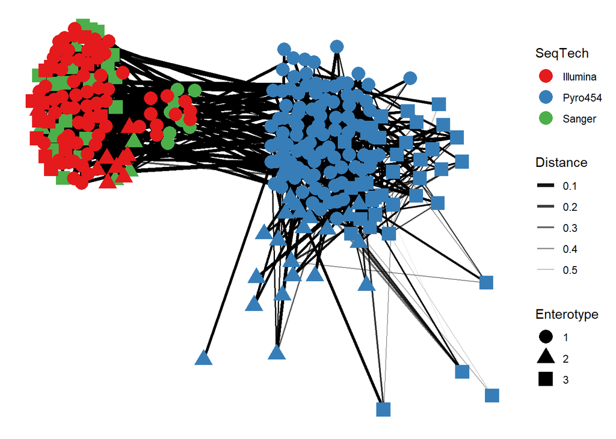

```r
plot_net(enterotype, maxdist = 0.6, color = "SeqTech", shape="Enterotype")
```

## The plot_network function

Make it

```r
ig <- make_network(enterotype, max.dist=0.3)
```

Plot it

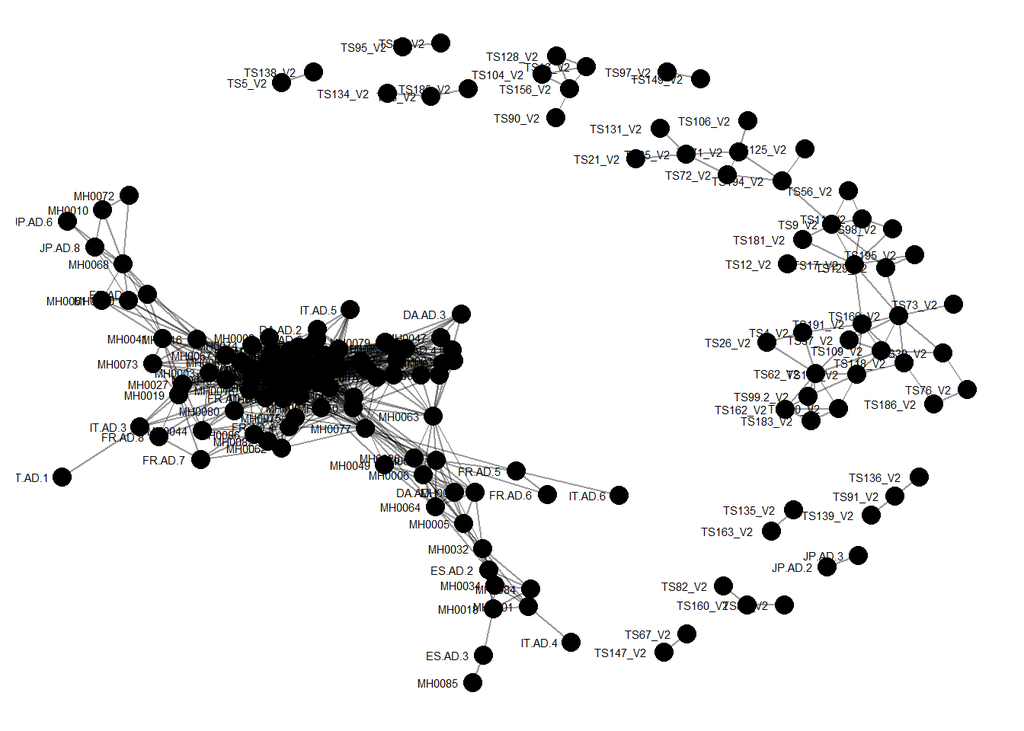

```r
plot_network(ig, enterotype)
```

Patterns in names and such again so let’s go back tousing colors and shapes to visualize

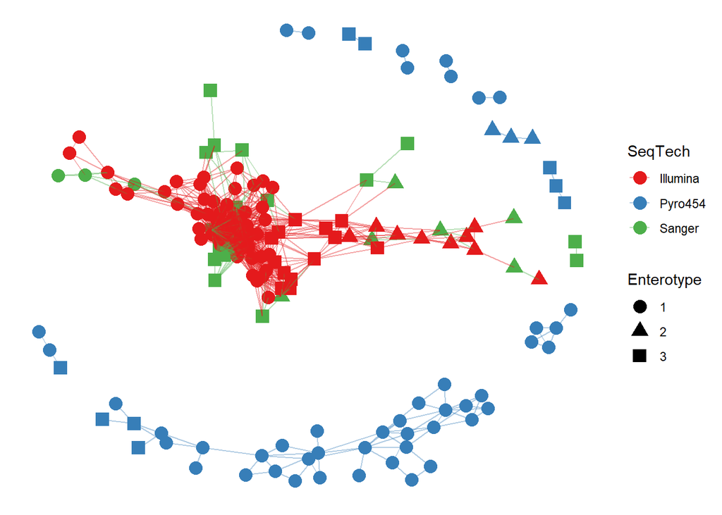

```r
plot_network(ig, enterotype, color="SeqTech", shape="Enterotype", line_weight=0.4, label=NULL)
```

Lower `max.dist`

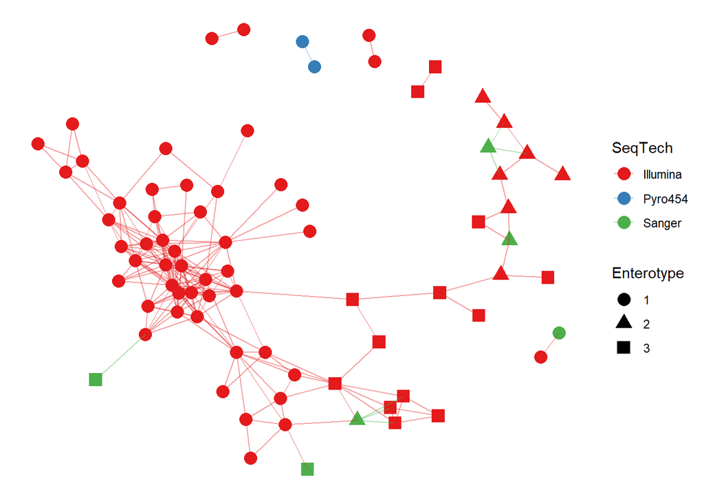

```r
ig <- make_network(enterotype, max.dist=0.2)
plot_network(ig, enterotype, color="SeqTech", shape="Enterotype", line_weight=0.4, label=NULL)
```

Try different methods

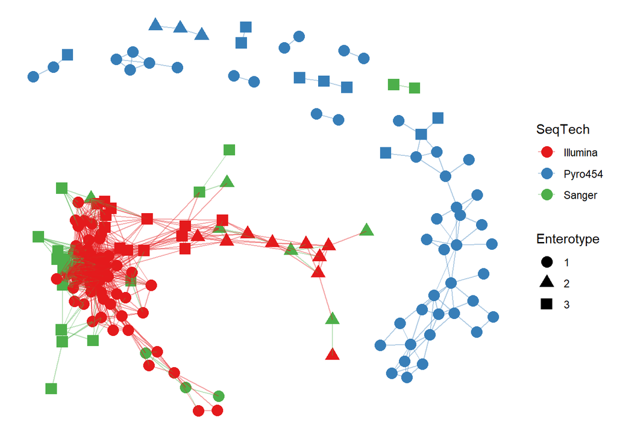

```r
ig <- make_network(enterotype, dist.fun="bray", max.dist=0.3)
plot_network(ig, enterotype, color="SeqTech", shape="Enterotype", line_weight=0.4, label=NULL)
```

Aaaaaaaaand that is the end of the tutorials.